# Salary Predictions Based on Job Descriptions

# Part 1 - DEFINE

### ---- 1 Define the problem ----

Use the results of career survey data to make accurate predcitions about the salary associated with each position.

```python
#import your libraries
import pandas as pd
from sklearn.ensemble import RandomForestRegressor, GradientBoostingRegressor
from sklearn.linear_model import LinearRegression, Lasso, Ridge, ElasticNet
from sklearn.svm import LinearSVR
import sklearn.preprocessing as preproc
import sklearn.model_selection as model_select
import sklearn.metrics as metrics
import numpy as np
import matplotlib.pyplot as plt
import seaborn as sns
from scipy.stats import randint as sp_randint
import time

__author__ = "Andy Gaworecki"
__email__ = "gaworecki5@gmail.com"
```

## Part 2 - DISCOVER

### ---- 2 Load the data ----

```python
train_features = pd.read_csv('data/train_features.csv')
train_salaries = pd.read_csv('data/train_salaries.csv')
test_features = pd.read_csv('data/test_features.csv')
```

### ---- 3 Clean the data ----

### Cleaning issues found:

- salaries outliers
  - remove rows with 0 salary, high outliers are valid data
- change categorical features to type categorical
- college graduates without majors
  - create new category for college graduates without majors 'undeclared' --> in feature engineering

#### Inspect the 3 data files

```python
train_features.head()
```

|  | jobId | companyId | jobType | degree | major | industry | yearsExperience | milesFromMetropolis |
| --- | --- | --- | --- | --- | --- | --- | --- | --- |
| 0 | JOB1362684407687 | COMP37 | CFO | MASTERS | MATH | HEALTH | 10 | 83 |
| 1 | JOB1362684407688 | COMP19 | CEO | HIGH_SCHOOL | NONE | WEB | 3 | 73 |
| 2 | JOB1362684407689 | COMP52 | VICE_PRESIDENT | DOCTORAL | PHYSICS | HEALTH | 10 | 38 |
| 3 | JOB1362684407690 | COMP38 | MANAGER | DOCTORAL | CHEMISTRY | AUTO | 8 | 17 |
| 4 | JOB1362684407691 | COMP7 | VICE_PRESIDENT | BACHELORS | PHYSICS | FINANCE | 8 | 16 |

```python
train_salaries.head()
```

|  | jobId | salary |
| --- | --- | --- |
| 0 | JOB1362684407687 | 130 |
| 1 | JOB1362684407688 | 101 |
| 2 | JOB1362684407689 | 137 |
| 3 | JOB1362684407690 | 142 |
| 4 | JOB1362684407691 | 163 |

```python
test_features.head()
```

|  | jobId | companyId | jobType | degree | major | industry | yearsExperience | milesFromMetropolis |
| --- | --- | --- | --- | --- | --- | --- | --- | --- |
| 0 | JOB1362685407687 | COMP33 | MANAGER | HIGH_SCHOOL | NONE | HEALTH | 22 | 73 |
| 1 | JOB1362685407688 | COMP13 | JUNIOR | NONE | NONE | AUTO | 20 | 47 |
| 2 | JOB1362685407689 | COMP10 | CTO | MASTERS | BIOLOGY | HEALTH | 17 | 9 |
| 3 | JOB1362685407690 | COMP21 | MANAGER | HIGH_SCHOOL | NONE | OIL | 14 | 96 |
| 4 | JOB1362685407691 | COMP36 | JUNIOR | DOCTORAL | BIOLOGY | OIL | 10 | 44 |

```python
train_features.info()
```

```
<class 'pandas.core.frame.DataFrame'>
RangeIndex: 1000000 entries, 0 to 999999
Data columns (total 8 columns):
jobId                  1000000 non-null object
companyId              1000000 non-null object
jobType                1000000 non-null object
degree                 1000000 non-null object
major                  1000000 non-null object
industry               1000000 non-null object
yearsExperience        1000000 non-null int64
milesFromMetropolis    1000000 non-null int64
dtypes: int64(2), object(6)
memory usage: 61.0+ MB
```

```python
train_salaries.info()
```

```
<class 'pandas.core.frame.DataFrame'>
RangeIndex: 1000000 entries, 0 to 999999
Data columns (total 2 columns):
jobId     1000000 non-null object
salary    1000000 non-null int64
dtypes: int64(1), object(1)
memory usage: 15.3+ MB
```

```python
test_features.info()
```

```
<class 'pandas.core.frame.DataFrame'>
RangeIndex: 1000000 entries, 0 to 999999
Data columns (total 8 columns):
jobId                  1000000 non-null object
companyId              1000000 non-null object
jobType                1000000 non-null object
degree                 1000000 non-null object
major                  1000000 non-null object
industry               1000000 non-null object
yearsExperience        1000000 non-null int64
milesFromMetropolis    1000000 non-null int64
dtypes: int64(2), object(6)
memory usage: 61.0+ MB
```

#### check for duplicates

```python
def check_duplicates(data_file):
    ''' function to check df for null values'''
    duplicates = data_file.duplicated().sum()
    print('This data file has a total of {} null values'.format(duplicates))
```

#### zero null values in any of the df

```python
data_files = [train_features, train_salaries, test_features]
for data in data_files:
    check_duplicates(data)
```

```
This data file has a total of 0 null values
This data file has a total of 0 null values
This data file has a total of 0 null values
```

### More inspection

#### jobID appears to be a unique identified and hence not useful in our analysis

```python
# get lists of numerical and catergorical features
categorical_cols = list(train_features.select_dtypes('object').columns)
number_cols = list(train_features.select_dtypes(np.number).columns)

#examine numerical an categorical features in more detail
print(train_features.describe())
print(train_features.describe(include= ['O']))
```

```
       yearsExperience  milesFromMetropolis
count   1000000.000000       1000000.000000
mean         11.992386            49.529260
std           7.212391            28.877733
min           0.000000             0.000000
25%           6.000000            25.000000
50%          12.000000            50.000000
75%          18.000000            75.000000
max          24.000000            99.000000
                   jobId companyId  jobType       degree    major industry
count            1000000   1000000  1000000      1000000  1000000  1000000
unique           1000000        63        8            5        9        7
top     JOB1362685273539    COMP39   SENIOR  HIGH_SCHOOL     NONE      WEB
freq                   1     16193   125886       236976   532355   143206
```

### Merge training features and target (salaries) together for convenience

### Remove jobId column - unique identifier not useful in prediction task

```python
train_df = train_features.merge(train_salaries, on = 'jobId')
train_df = train_df.drop(columns=['jobId'])
```

### Outliers in target variable

```python
train_df.describe().salary
```

```
count    1000000.000000
mean         116.061818
std           38.717936
min            0.000000
25%           88.000000
50%          114.000000
75%          141.000000
max          301.000000
Name: salary, dtype: float64
```

```python
# Use IQR to locate high and low outliers
mean = train_df.describe().salary['mean']
IQR = train_df.describe().salary['75%'] - train_df.describe().salary['25%']
top = train_df.describe().salary['75%'] + 1.5*IQR
bottom = train_df.describe().salary['25%'] - 1.5*IQR
print("Salary Outliers lie below {} and above {}".format(bottom, top))
```

```
Salary Outliers lie below 8.5 and above 220.5
```

### Look at outiers in detail

##### Bottom end outliers have a salary = 0 with no logical reason --> remove from data

```python
train_df.loc[train_df.salary < 8.5]
```

|  | companyId | jobType | degree | major | industry | yearsExperience | milesFromMetropolis | salary |
| --- | --- | --- | --- | --- | --- | --- | --- | --- |
| 30559 | COMP44 | JUNIOR | DOCTORAL | MATH | AUTO | 11 | 7 | 0 |
| 495984 | COMP34 | JUNIOR | NONE | NONE | OIL | 1 | 25 | 0 |
| 652076 | COMP25 | CTO | HIGH_SCHOOL | NONE | AUTO | 6 | 60 | 0 |
| 816129 | COMP42 | MANAGER | DOCTORAL | ENGINEERING | FINANCE | 18 | 6 | 0 |
| 828156 | COMP40 | VICE_PRESIDENT | MASTERS | ENGINEERING | WEB | 3 | 29 | 0 |

```python
#drop the 5 rows where salary is zero
train_df = train_df.loc[train_df.salary > 8.5]
```

##### Top end outliers appear to be high paying regular jobs so they need to remain in the data

```python
train_df.loc[train_df.salary > 220.5].head()
```

|  | companyId | jobType | degree | major | industry | yearsExperience | milesFromMetropolis | salary |
| --- | --- | --- | --- | --- | --- | --- | --- | --- |
| 266 | COMP30 | CEO | MASTERS | BIOLOGY | OIL | 23 | 60 | 223 |
| 362 | COMP38 | CTO | MASTERS | NONE | HEALTH | 24 | 3 | 223 |
| 560 | COMP53 | CEO | MASTERS | BIOLOGY | WEB | 22 | 7 | 248 |
| 670 | COMP26 | CEO | MASTERS | MATH | AUTO | 23 | 9 | 240 |
| 719 | COMP54 | VICE_PRESIDENT | DOCTORAL | BIOLOGY | OIL | 21 | 14 | 225 |

#### Change all categorical variables to type category

```python
for col in list(train_df.select_dtypes('object').columns):
    train_df[col] = train_df[col].astype('category')
```

### ---- 4 Explore the data (EDA) ----

```python
#summarize each feature variable
#summarize the target variable
#look for correlation between each feature and the target
#look for correlation between features
```

### Visualize target variable

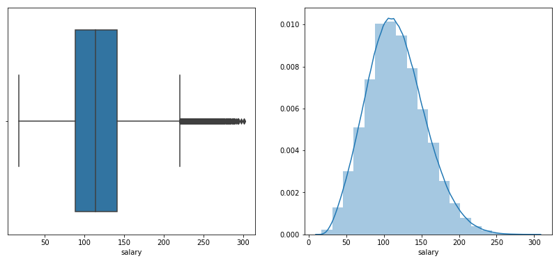

```python
plt.figure(figsize = (14, 6))
plt.subplot(1,2,1)
sns.boxplot(train_df.salary)
plt.subplot(1,2,2)
sns.distplot(train_df.salary, bins=20)
plt.show()
```

### Visualize each feature

```python
def plot_feature(df, col):
    '''
    Make plot for each features
    left, the distribution of samples on the feature
    right, the dependance of salary on the feature
    '''
    plt.figure(figsize = (14, 6))
    plt.subplot(1, 2, 1)
    if df[col].dtype == 'int64':
        df[col].value_counts().sort_index().plot()
    else:
        #change the categorical variable to category type and order their level by the mean salary
        #in each category
        mean = df.groupby(col)['salary'].mean()
        #df[col] = df[col].astype('category')
        levels = mean.sort_values().index.tolist()
        df[col].cat.reorder_categories(levels, inplace=True)
        df[col].value_counts().plot()
    plt.xticks(rotation=45)
    plt.xlabel(col)
    plt.ylabel('Counts')
    plt.subplot(1, 2, 2)

    if df[col].dtype == 'int64' or col == 'companyId':
        #plot the mean salary for each category and fill between the (mean - std, mean + std)
        mean = df.groupby(col)['salary'].mean()
        std = df.groupby(col)['salary'].std()
        mean.plot()
        plt.fill_between(range(len(std.index)), mean.values-std.values, mean.values + std.values, \
                         alpha = 0.1)
    else:
        sns.boxplot(x = col, y = 'salary', data=df)

    plt.xticks(rotation=45)
    plt.ylabel('Salaries')
    plt.show()
```

##### relatively even spread of experience in the data and clear positive correlation of yearsExperience with salary

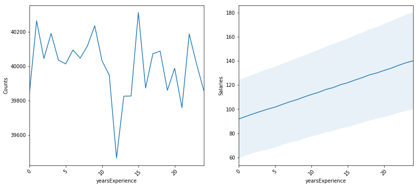

```python
plot_feature(train_df, 'yearsExperience')
```

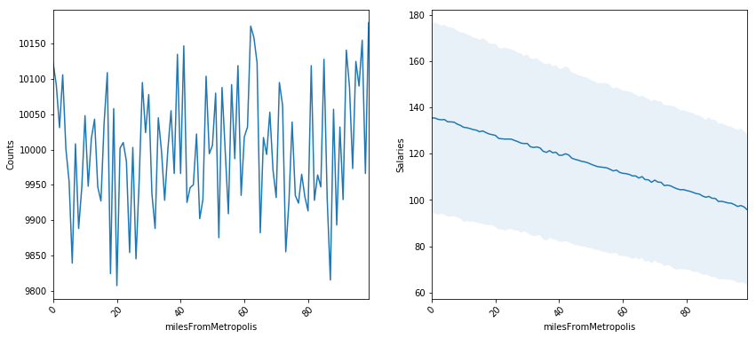

```python
plot_feature(train_df, 'milesFromMetropolis')
```

##### balanced spread of different job types - clear upward trend in salaries that meets expectations

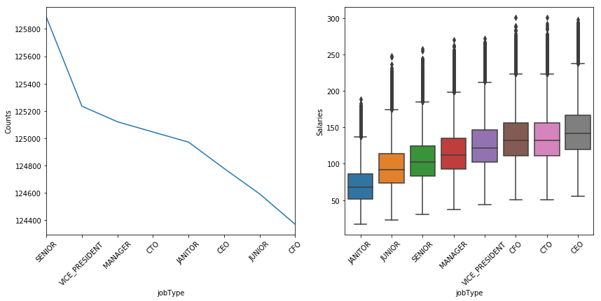

```python
plot_feature(train_df, 'jobType')
```

#### less people with higher degrees as expected - higher degrees seem to earn more as well

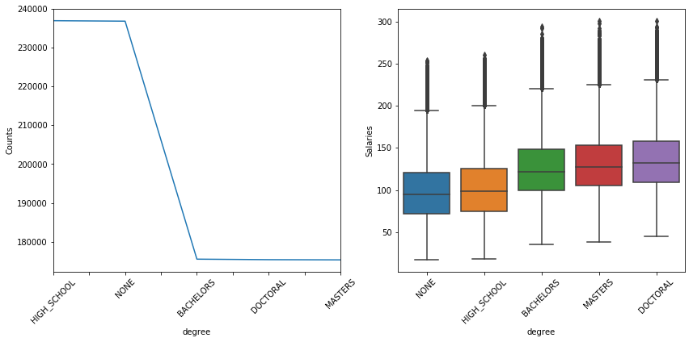

```python
plot_feature(train_df, 'degree')
```

#### not surprizingly education has lowest salaries and oil and finance have the highest

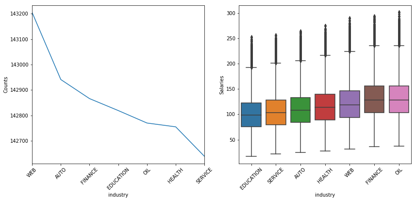

```python
plot_feature(train_df, 'industry')
```

#### As expected - No major has the lowest salaries and business and engineering have among hte highest but a good amount of overlap in these ranges

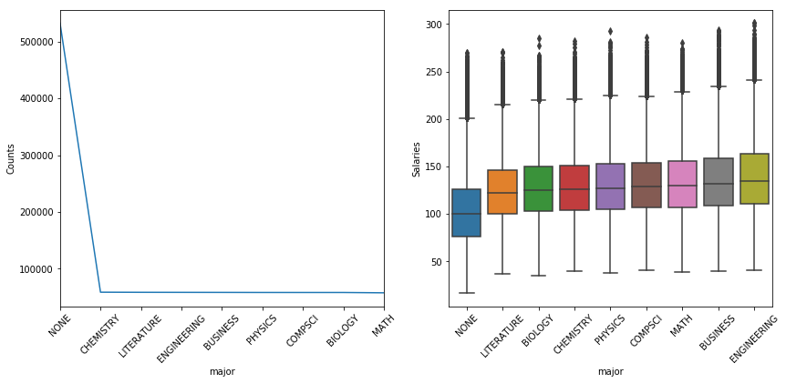

```python
plot_feature(train_df, 'major')
```

#### No correlation beween companyId and salaries

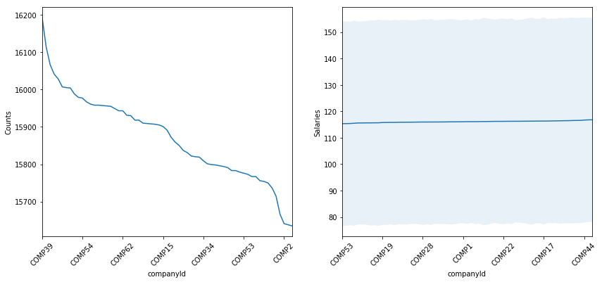

```python
plot_feature(train_df, 'companyId')
```

```python
train_df.head()
```

|  | companyId | jobType | degree | major | industry | yearsExperience | milesFromMetropolis | salary |
| --- | --- | --- | --- | --- | --- | --- | --- | --- |
| 0 | COMP37 | CFO | MASTERS | MATH | HEALTH | 10 | 83 | 130 |
| 1 | COMP19 | CEO | HIGH_SCHOOL | NONE | WEB | 3 | 73 | 101 |
| 2 | COMP52 | VICE_PRESIDENT | DOCTORAL | PHYSICS | HEALTH | 10 | 38 | 137 |
| 3 | COMP38 | MANAGER | DOCTORAL | CHEMISTRY | AUTO | 8 | 17 | 142 |
| 4 | COMP7 | VICE_PRESIDENT | BACHELORS | PHYSICS | FINANCE | 8 | 16 | 163 |

### Look for correlations between features and with salary

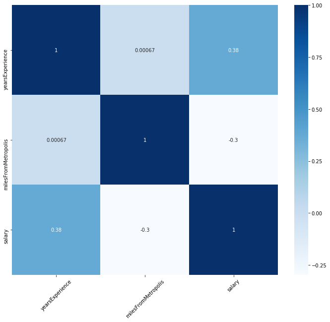

```python
# Correlations between selected features and response
# jobId is discarded because it is unique for individual
fig = plt.figure(figsize=(12, 10))
features = ['companyId', 'jobType', 'major', 'industry', 'yearsExperience', 'milesFromMetropolis'] #, 'degree_OE'
sns.heatmap(train_df[features + ['salary']].corr(), cmap='Blues', annot=True)
plt.xticks(rotation=45)
plt.show()
```

### ---- 5 Establish a baseline ----

- baseline model = naive prediction that all salaries will be equal to the mean for that jobType
- Use 5-fold cross-validation
- error metric = MSE - simple error metric for regression analysis and easy to interpret

```python
#baseline model
#predict salary naively as the average for each job type

def naive_encode(df, col, new_col ='base_predict'):
    ''' create new column in df for baseline predictions'''
    cat_dict ={}
    cat_salaries = df.groupby(col).salary.mean()
    cats = df[col].cat.categories.tolist()
    for cat in cats:
        cat_dict[cat] = cat_salaries[cat]
    df[new_col] = df[col].map(cat_dict)
```

```python
#create new df for baseline error metric
baseline_df = train_df.copy()
naive_encode(baseline_df, 'jobType')
baseline_df.head()
```

|  | companyId | jobType | degree | major | industry | yearsExperience | milesFromMetropolis | salary | base_predict |
| --- | --- | --- | --- | --- | --- | --- | --- | --- | --- |
| 0 | COMP37 | CFO | MASTERS | MATH | HEALTH | 10 | 83 | 130 | 135.458547 |
| 1 | COMP19 | CEO | HIGH_SCHOOL | NONE | WEB | 3 | 73 | 101 | 145.311425 |
| 2 | COMP52 | VICE_PRESIDENT | DOCTORAL | PHYSICS | HEALTH | 10 | 38 | 137 | 125.368630 |
| 3 | COMP38 | MANAGER | DOCTORAL | CHEMISTRY | AUTO | 8 | 17 | 142 | 115.368518 |
| 4 | COMP7 | VICE_PRESIDENT | BACHELORS | PHYSICS | FINANCE | 8 | 16 | 163 | 125.368630 |

```python
# calculate MSE for baseline prediction
metrics.mean_squared_error(baseline_df.base_predict, baseline_df.salary)
```

```
963.9252996562975
```

### ---- 6 Hypothesize solution ----

Models

- I will try three regression models because even though the target variable is discrete task is very similar to regression. I will compare those with two tree based models because most of the features are categorical in nature and to see which yeilds the best predictions.
- Tree models - Random Forest Regressor & Gradient Boosted Regressor
- Linear Regression - linear regression, linear SVR, ElasticNet Regression

Features

- scale numeric features (may not be neccessary for tree models)
- encode degree ordinally
- one hot encode reamining categorical features
- possibly create a new category for degreee feature for people who attended college but have degree listed as NONE

## Part 3 - DEVELOP

You will cycle through creating features, tuning models, and training/validing models (steps 7-9) until you've reached your efficacy goal

#### Your metric will be MSE and your goal is:

- <360 for entry-level data science roles
- <320 for senior data science roles

### ---- 7 Engineer features ----

### Categorical Features

#### Create new category 'UNDECLARED' for records with college degree but no major listed

```python
# train_df.major.cat.add_categories(new_categories=['UNDECLARED'], inplace = True)
# train_df.major.cat.categories
```

```python
#Encode degree as ordinal catergory
age_ord_map = {'NONE': 0.0, 'HIGH_SCHOOL': 1, 'BACHELORS': 2, 'MASTERS': 3, 'DOCTORAL': 4}

train_df['degree_OE'] = train_df['degree'].map(age_ord_map)
train_df.head()
```

|  | companyId | jobType | degree | major | industry | yearsExperience | milesFromMetropolis | salary | degree_OE |
| --- | --- | --- | --- | --- | --- | --- | --- | --- | --- |
| 0 | COMP37 | CFO | MASTERS | MATH | HEALTH | 10 | 83 | 130 | 3.0 |
| 1 | COMP19 | CEO | HIGH_SCHOOL | NONE | WEB | 3 | 73 | 101 | 1.0 |
| 2 | COMP52 | VICE_PRESIDENT | DOCTORAL | PHYSICS | HEALTH | 10 | 38 | 137 | 4.0 |
| 3 | COMP38 | MANAGER | DOCTORAL | CHEMISTRY | AUTO | 8 | 17 | 142 | 4.0 |
| 4 | COMP7 | VICE_PRESIDENT | BACHELORS | PHYSICS | FINANCE | 8 | 16 | 163 | 2.0 |

### Label Encoding of categorical - Not Here

```python
# #encoding degree as label encoded --> no good
# from sklearn.preprocessing import LabelEncoder
# le = LabelEncoder()
# degree_labels = le.fit_transform(train_df.degree)
# train_df['degree_LE'] = degree_labels
# train_df[['degree','degree_LE']].head()
```

### One hot encoding of remaining categoricals

```python
#encode all other categoricals as one-hot because they do not have order
# do not use companyID because of low correlation with salary
one_hot_columns = ['jobType','major','industry']
train_df = pd.get_dummies(train_df, columns=one_hot_columns)
```

### Numeric Features

```python
#Simple scaling - StandardScaler or MinMaxSaler

for col in number_cols:
    scaler = preproc.StandardScaler()
    train_df[col+'_scale'] = scaler.fit_transform(train_df[[col]])
```

### ---- 8 Create models ----

Create df's for features and target for training

```python
target = train_df['salary']
#drop target variable and unformatted feature varaibles from features data
features = train_df.drop(columns=['salary','companyId','degree','yearsExperience','milesFromMetropolis'])
```

```python
features.head()
```

|  | degree_OE | jobType_JANITOR | jobType_JUNIOR | jobType_SENIOR | jobType_MANAGER | jobType_VICE_PRESIDENT | jobType_CFO | jobType_CTO | jobType_CEO | major_NONE | ... | major_ENGINEERING | industry_EDUCATION | industry_SERVICE | industry_AUTO | industry_HEALTH | industry_WEB | industry_FINANCE | industry_OIL | yearsExperience_scale | milesFromMetropolis_scale |
| --- | --- | --- | --- | --- | --- | --- | --- | --- | --- | --- | --- | --- | --- | --- | --- | --- | --- | --- | --- | --- | --- |
| 0 | 3.0 | 0 | 0 | 0 | 0 | 0 | 1 | 0 | 0 | 0 | ... | 0 | 0 | 0 | 0 | 1 | 0 | 0 | 0 | -0.276248 | 1.159047 |
| 1 | 1.0 | 0 | 0 | 0 | 0 | 0 | 0 | 0 | 1 | 1 | ... | 0 | 0 | 0 | 0 | 0 | 1 | 0 | 0 | -1.246801 | 0.812759 |
| 2 | 4.0 | 0 | 0 | 0 | 0 | 1 | 0 | 0 | 0 | 0 | ... | 0 | 0 | 0 | 0 | 1 | 0 | 0 | 0 | -0.276248 | -0.399248 |
| 3 | 4.0 | 0 | 0 | 0 | 1 | 0 | 0 | 0 | 0 | 0 | ... | 0 | 0 | 0 | 1 | 0 | 0 | 0 | 0 | -0.553549 | -1.126453 |
| 4 | 2.0 | 0 | 0 | 0 | 0 | 1 | 0 | 0 | 0 | 0 | ... | 0 | 0 | 0 | 0 | 0 | 0 | 1 | 0 | -0.553549 | -1.161082 |

5 rows × 27 columns

Create models

```python
#Instantiate basic models for regression prediction
model_lr = LinearRegression()
model_elastic = ElasticNet()
model_rf = RandomForestRegressor(n_estimators = 30)
model_svr = LinearSVR()
model_gbr = GradientBoostingRegressor()

model_list = [model_lr, model_elastic, model_svr, model_rf, model_gbr]
```

```python
model_lasso.get_params()
```

```
{'alpha': 1.0,
 'copy_X': True,
 'fit_intercept': True,
 'max_iter': 1000,
 'normalize': False,
 'positive': False,
 'precompute': False,
 'random_state': None,
 'selection': 'cyclic',
 'tol': 0.0001,
 'warm_start': False}
```

### ---- 9 Test models ----

```python
def run_model(model ,cv=5, scorer = 'neg_mean_squared_error', n_jobs =2):
    ''' function to run model and output cross-validated error metric stats and run time'''
    start = time.time()
    model_score = model_select.cross_val_score(model, features, target, cv=cv, scoring = scorer, n_jobs =n_jobs)
    run_time = time.time() - start
    print('{} model - average MSE: {:06.2f}, Stdev: {:05.2f}  (5_fold cross-validation)'.
          format(str(model).split('(')[0], -(model_score.mean()), model_score.std()))
    print('Model CV run time : {:06.2f} seconds'.format(run_time))
```

```python
#loop through models to get MSE for each
for model in model_list:
    run_model(model)
```

```
LinearRegression model - average MSE: 384.59, Stdev: 01.79  (5_fold cross-validation)
Model CV run time : 014.08 seconds
ElasticNet model - average MSE: 818.59, Stdev: 03.91  (5_fold cross-validation)
Model CV run time : 006.36 seconds
```

```
LinearSVR model - average MSE: 385.58, Stdev: 01.89  (5_fold cross-validation)
Model CV run time : 021.42 seconds
RandomForestRegressor model - average MSE: 448.46, Stdev: 01.89  (5_fold cross-validation)
Model CV run time : 585.00 seconds
GradientBoostingRegressor model - average MSE: 374.19, Stdev: 01.40  (5_fold cross-validation)
Model CV run time : 471.91 seconds
```

### ---- 10 Select best model ----

Gradient Boosted Regression - lowest out of the box MSE = 374.19

- tuning hyperparameters

## Tune the tree models

- gradient boosting regressor
- random forest regressor
- Tune on:
  - n_estimators, max_depth, max_features, min_samples_split

```python
# tune random forest regressor hyperparameters
# max features - general rule = np.sqrt(features.shape[1] = 5
param_dist = {"n_estimators":sp_randint(60, 150),
              "max_depth": sp_randint(3, 10),
              "max_features": sp_randint(3, 20),
              "min_samples_split": sp_randint(6, 20),}

n_iter_search = 10
random_search_rf = model_select.RandomizedSearchCV(model_rf, param_distributions=param_dist,
                                n_jobs =1, verbose=5, n_iter=n_iter_search, cv=3, iid=True
                                               ,scoring='neg_mean_squared_error')

random_search_rf.fit(features, target)
```

```
Fitting 3 folds for each of 10 candidates, totalling 30 fits
[CV] max_depth=3, max_features=7, min_samples_split=16, n_estimators=90
```

```
[Parallel(n_jobs=1)]: Using backend SequentialBackend with 1 concurrent workers.
```

```
[CV]  max_depth=3, max_features=7, min_samples_split=16, n_estimators=90, score=-853.9079118485004, total=  19.6s
[CV] max_depth=3, max_features=7, min_samples_split=16, n_estimators=90
```

```
[Parallel(n_jobs=1)]: Done   1 out of   1 | elapsed:   21.9s remaining:    0.0s
```

```
[CV]  max_depth=3, max_features=7, min_samples_split=16, n_estimators=90, score=-843.7326666120888, total=  19.7s
[CV] max_depth=3, max_features=7, min_samples_split=16, n_estimators=90
```

```
[Parallel(n_jobs=1)]: Done   2 out of   2 | elapsed:   43.9s remaining:    0.0s
```

```
[CV]  max_depth=3, max_features=7, min_samples_split=16, n_estimators=90, score=-850.1729225595955, total=  18.8s
[CV] max_depth=4, max_features=13, min_samples_split=19, n_estimators=77
```

```
[Parallel(n_jobs=1)]: Done   3 out of   3 | elapsed:  1.1min remaining:    0.0s
```

```
[CV]  max_depth=4, max_features=13, min_samples_split=19, n_estimators=77, score=-717.6075503646828, total=  32.4s
[CV] max_depth=4, max_features=13, min_samples_split=19, n_estimators=77
```

```
[Parallel(n_jobs=1)]: Done   4 out of   4 | elapsed:  1.7min remaining:    0.0s
```

[output not shown]

```
[Parallel(n_jobs=1)]: Done  30 out of  30 | elapsed: 34.5min finished
```

```
RandomizedSearchCV(cv=3, error_score='raise-deprecating',
          estimator=RandomForestRegressor(bootstrap=True, criterion='mse', max_depth=None,
           max_features='auto', max_leaf_nodes=None,
           min_impurity_decrease=0.0, min_impurity_split=None,
           min_samples_leaf=1, min_samples_split=2,
           min_weight_fraction_leaf=0.0, n_estimators=30, n_jobs=None,
           oob_score=False, random_state=None, verbose=0, warm_start=False),
          fit_params=None, iid=True, n_iter=10, n_jobs=1,
          param_distributions={'n_estimators': <scipy.stats._distn_infrastructure.rv_frozen object at 0x7f955050a7b8>, 'max_depth': <scipy.stats._distn_infrastructure.rv_frozen object at 0x7f955050a2b0>, 'max_features': <scipy.stats._distn_infrastructure.rv_frozen object at 0x7f955050ac18>, 'min_sam…
          pre_dispatch='2*n_jobs', random_state=None, refit=True,
          return_train_score='warn', scoring='neg_mean_squared_error',
          verbose=5)
```

```python
best_model_rf = random_search_rf.best_estimator_
#answer['split0_test_score'].mean()
best_score_rf = random_search_rf.best_score_
best_model_rf, best_score_rf
```

```
(RandomForestRegressor(bootstrap=True, criterion='mse', max_depth=9,
            max_features=12, max_leaf_nodes=None, min_impurity_decrease=0.0,
            min_impurity_split=None, min_samples_leaf=1,
            min_samples_split=13, min_weight_fraction_leaf=0.0,
            n_estimators=104, n_jobs=None, oob_score=False,
            random_state=None, verbose=0, warm_start=False),
 -457.0399623202161)
```

```python
# tune hyperparameter for gradient boosting regressor

# specify parameters and distributions to sample from
param_dist = {"n_estimators":sp_randint(60, 150),
              "max_depth": sp_randint(3, 10),
              "max_features": sp_randint(3, 20),
              "min_samples_split": sp_randint(6, 20),}

# run randomized search
n_iter_search = 20
random_search_gbr = model_select.RandomizedSearchCV(model_gbr, param_distributions=param_dist,
                                n_jobs =1, verbose=5, n_iter=n_iter_search, cv=3, iid=True
                                               ,scoring='neg_mean_squared_error')

start = time.time()
random_search_gbr.fit(features, target)
```

```
Fitting 3 folds for each of 20 candidates, totalling 60 fits
[CV] max_depth=9, max_features=16, min_samples_split=19, n_estimators=65
```

```
[Parallel(n_jobs=1)]: Using backend SequentialBackend with 1 concurrent workers.
```

```
[CV]  max_depth=9, max_features=16, min_samples_split=19, n_estimators=65, score=-359.96749674805636, total= 8.4min
[CV] max_depth=9, max_features=16, min_samples_split=19, n_estimators=65
```

```
[Parallel(n_jobs=1)]: Done   1 out of   1 | elapsed:  8.4min remaining:    0.0s
```

```
[CV]  max_depth=9, max_features=16, min_samples_split=19, n_estimators=65, score=-359.02842912663044, total= 8.4min
[CV] max_depth=9, max_features=16, min_samples_split=19, n_estimators=65
```

```
[Parallel(n_jobs=1)]: Done   2 out of   2 | elapsed: 16.9min remaining:    0.0s
```

```
[CV]  max_depth=9, max_features=16, min_samples_split=19, n_estimators=65, score=-357.2506190920632, total= 8.5min
[CV] max_depth=5, max_features=15, min_samples_split=6, n_estimators=129
```

```
[Parallel(n_jobs=1)]: Done   3 out of   3 | elapsed: 25.4min remaining:    0.0s
```

```
[CV]  max_depth=5, max_features=15, min_samples_split=6, n_estimators=129, score=-360.12057773565914, total= 2.7min
[CV] max_depth=5, max_features=15, min_samples_split=6, n_estimators=129
```

```
[Parallel(n_jobs=1)]: Done   4 out of   4 | elapsed: 28.1min remaining:    0.0s
```

[output not shown]

[output cut: 56 more lines]

```
[CV]  max_depth=9, max_features=8, min_samples_split=9, n_estimators=125, score=-358.55975278340844, total=12.9min
[CV] max_depth=9, max_features=8, min_samples_split=9, n_estimators=125
[CV]  max_depth=9, max_features=8, min_samples_split=9, n_estimators=125, score=-356.8169266635604, total=11.2min
[CV] max_depth=9, max_features=11, min_samples_split=9, n_estimators=63
[CV]  max_depth=9, max_features=11, min_samples_split=9, n_estimators=63, score=-360.5671656784224, total= 7.8min
[CV] max_depth=9, max_features=11, min_samples_split=9, n_estimators=63
[CV]  max_depth=9, max_features=11, min_samples_split=9, n_estimators=63, score=-359.81698071625783, total= 7.9min
[CV] max_depth=9, max_features=11, min_samples_split=9, n_estimators=63
[CV]  max_depth=9, max_features=11, min_samples_split=9, n_estimators=63, score=-358.08070901988003, total= 7.1min
[CV] max_depth=3, max_features=7, min_samples_split=6, n_estimators=99
[CV]  max_depth=3, max_features=7, min_samples_split=6, n_estimators=99, score=-386.03036050327205, total=  29.9s
[CV] max_depth=3, max_features=7, min_samples_split=6, n_estimators=99
[CV]  max_depth=3, max_features=7, min_samples_split=6, n_estimators=99, score=-383.23540627157547, total=  29.5s
[CV] max_depth=3, max_features=7, min_samples_split=6, n_estimators=99
[CV]  max_depth=3, max_features=7, min_samples_split=6, n_estimators=99, score=-383.6075693033594, total=  29.9s
```

```
[Parallel(n_jobs=1)]: Done  60 out of  60 | elapsed: 309.8min finished
```

```
RandomizedSearchCV(cv=3, error_score='raise-deprecating',
          estimator=GradientBoostingRegressor(alpha=0.9, criterion='friedman_mse', init=None,
             learning_rate=0.1, loss='ls', max_depth=3, max_features=None,
             max_leaf_nodes=None, min_impurity_decrease=0.0,
             min_impurity_split=None, min_samples_leaf=1,
             min_sampl...=None, subsample=1.0, tol=0.0001,
             validation_fraction=0.1, verbose=0, warm_start=False),
          fit_params=None, iid=True, n_iter=20, n_jobs=1,
          param_distributions={'n_estimators': <scipy.stats._distn_infrastructure.rv_frozen object at 0x7f95505363c8>, 'max_depth': <scipy.stats._distn_infrastructure.rv_frozen object at 0x7f9550536d30>, 'max_features': <scipy.stats._distn_infrastructure.rv_frozen object at 0x7f9550536a20>, 'min_sam…
          pre_dispatch='2*n_jobs', random_state=None, refit=True,
          return_train_score='warn', scoring='neg_mean_squared_error',
          verbose=5)
```

```python
best_model_gbr = random_search_gbr.best_estimator_
#answer['split0_test_score'].mean()
best_score_gbr = random_search_gbr.best_score_
best_model_gbr, best_score_gbr
```

```
(GradientBoostingRegressor(alpha=0.9, criterion='friedman_mse', init=None,
              learning_rate=0.1, loss='ls', max_depth=8, max_features=12,
              max_leaf_nodes=None, min_impurity_decrease=0.0,
              min_impurity_split=None, min_samples_leaf=1,
              min_samples_split=15, min_weight_fraction_leaf=0.0,
              n_estimators=125, n_iter_no_change=None, presort='auto',
              random_state=None, subsample=1.0, tol=0.0001,
              validation_fraction=0.1, verbose=0, warm_start=False),
 -357.5992057965531)
```

## Part 4 - DEPLOY

### ---- 11 Automate pipeline ----

```python
#write script that trains model on entire training set, saves model to disk,
#and scores the "test" dataset

#define functions

def load_data(data_file):
    '''function to read a csv into a df'''
    return pd.read_csv(data_file)

def merge_clean_data(features_df, target_df):
    '''function to merge features df with target df'''
    #merge features and target
    train_df = features_df.merge(target_df, on = 'jobId')
    #remove outliers with incorrect 0 salary
    train_df = train_df.loc[train_df.salary > 8.5]
    #change column type to categorical
    for col in list(train_df.select_dtypes('object').columns):
        train_df[col] = train_df[col].astype('category')
    return train_df

def feature_encode_scale(train_df):
    '''function to encode features:
    1. encode degree ordinaly
    2. drop low correlation features jobId and companyId
    3. encode other categoricals as one-hot
    4. scale numeric cols'''

    # ecode degree column ordinal
    degree_ord_map = {'NONE': 0.0, 'HIGH_SCHOOL': 1, 'BACHELORS': 2,
                      'MASTERS': 3, 'DOCTORAL': 4}
    train_df['degree'] = train_df['degree'].map(degree_ord_map)

    #drop columns with low correlation
    train_df = train_df.drop(columns=['jobId','companyId'])

    # encode remaining categoricals as one-hot
    one_hot_columns = ['jobType','major','industry']
    train_df = pd.get_dummies(train_df, columns=one_hot_columns)

    #scale numeric cols with StandardScalerScaler
    number_cols = ['milesFromMetropolis','yearsExperience']
    for col in number_cols:
        scaler = preproc.StandardScaler()
        train_df[col] = scaler.fit_transform(train_df[[col]])
    return train_df

def train_model(model, train_df):
    '''function to train model on df with features and target variables'''
    #split train_df into target_df and features_df
    target_df = train_df.loc[:, 'salary']
    features_df = train_df.drop(columns=['salary'])
    model.fit(features_df, target_df)

def get_predictions(model, test_df):
    '''function to preprocess test_df and make predictions from features'''
    predict_df = feature_encode_scale(test_df)
    predictions = model.predict(predict_df)
    return predictions

def get_importances_viz(trained_model):
    '''get features importances (dataframe) from a trained model and
    create a visualization'''
    try:
        importances = trained_model.feature_importances_
        importances_df = pd.DataFrame({'feature':train_df.drop(columns=['salary']).columns, 'importance':importances})
        importances_df.sort_values(by='importance', ascending=False,inplace = True)
        importances_df.set_index('feature', inplace=True, drop=True)
        viz = importances_df[0:20].plot.bar(figsize=(20,10));
    except:
        importances = [0]*len(train_df.drop(columns=['salary']).columns)
        viz = None
    return importances_df, viz

def save_model(best_model, importances_df, importances_viz, predictions):
    '''save model, feature importances & viz, and predictions'''
    with open('best_model.txt', 'w') as file:
        file.write(str(model))
    importances_df.to_csv('feature_importances.csv')
    importances_viz.savefig('feature_importances.png')
    pd.DataFrame(predictions, columns=['predictions']).to_csv('prediction.csv')
```

```python
# run script

#load the data
train_features = load_data('data/train_features.csv')
train_salaries = load_data('data/train_salaries.csv')
test_features = load_data('data/test_features.csv')

#clean data
train_df = merge_clean_data(train_features, train_salaries)

#feature engineering and encoding
train_df = feature_encode_scale(train_df)

#best model - previously tuned
gbr_model = GradientBoostingRegressor(max_depth=8, max_features=12,
                                      min_samples_split=15,
                                      n_estimators=125)

#train best model and make predictions on test_df
train_model(gbr_model, train_df)
predictions = get_predictions(gbr_model, test_features)

#get feature importances and create visualization
feature_importances, features_viz = get_importances_viz(gbr_model)
```

### ---- 12 Deploy solution ----

```python
#save model, feature_importances and predictions to csv files
#save importances visualization to png file
save_model(gbr_model, feature_importances, features_viz, predictions)
```

### ---- 13 Measure efficacy ----

We'll skip this step since we don't have the outcomes for the test data